# Relatório de Análise de Bioequivalência: Estudo Cross-over 2x2

Pedro A. G. Contardi

2025-05-05

## Introdução

O seguinte relatório foi elaborado para explicar e avaliar a bioequivalência entre dois fármacos (**referência** e **teste**) em um desenho cross-over 2x2.

## História da Biodisponibilidade/Bioequivalência

Os estudos de biodisponibilidade começaram oficialmente em 1945, com a introdução do termo “disponibilidade biológica”. Entre 1960-1970, ocorreu o desenvolvimento de novas técnicas analíticas mais sensíveis, que permitiu medir fármacos no sangue e comparar as formulações.

Em 1970, no **Canadá**, a bioequivalência passou a ser usada como um critério regulatório e logo depois em 1977, foi adotada pela **FDA (EUA)**, sendo fortalecida em 1984 por uma lei que permite a aprovação de genéricos sem testes clínicos, desde que fossem bioequivalentes ao original.

No **Brasil**, só depois da criação da **Lei dos Genéricos**, em 1999, esse tipo de avaliação virou padrão. O professor Gilberto de Nucci foi peça-chave nesse processo, montando uma estrutura pioneira na Unicamp e formando boa parte dos especialistas que atuam na área hoje.

Resumindo, esses estudos servem para saber **quanto, e com que velocidade**, uma substância ativa entra na circulação e está pronta para agir no corpo. A medição é feita com base nos níveis da substância no sangue ao longo do tempo.

## Importância da Bioequivalência

Bioequivalência é fundamental para assegurar que duas formulações que contêm o mesmo princípio ativo, geralmente o medicamento de marca (**referência**) e um **genérico**, possuem o mesmo comportamento dentro do organismo. Ou seja, liberam a substância ativa com a mesma velocidade e quantidade, atingindo concentrações semelhantes no sangue ao longo do tempo.

Os pontos abaixo reforçam a importância desse estudo:

- **Intercambialidade entre medicamentos:** Ser bioequivalentes garante a capacidade de trocar um medicamento por outro equivalente – normalmente um genérico substituindo o de marca - sem comprometer o tratamento.
- **Necessário para aprovações regulatórias:** Tanto a **ANVISA (Brasil)** e **FDA (EUA)** e outras agências internacionais exigem estudos de bioequivalência como etapa **obrigatória** para aprovar medicamentos genéricos.
- **Base para aprovação de genéricos:** Sem bioequivalência, não existe genérico aprovado. O conceito de ser genérico só é valido quando ele é clinicamente equivalente ao original, mesmo sem ter passado por todos os ensaios clínicos. Por isso que os estudos de bioequivalência é a principal ferramenta cientifica que valida o uso de genéricos.

## Planejamento Experimental: Cross-over 2x2

É o planejamento padrão usado em estudos de bioequivalência. Cada voluntário recebe os dois tratamentos, em momentos diferentes, com uma pausa entre eles (período de washout), para evitar a interferência do primeiro na resposta do segundo.

- **Dois tratamentos:** O medicamento de referência (R) e o teste (T) – geralmente o genérico.
- **Dois períodos:** O estudo tem duas fases de administração.
- **Duas Sequências de tratamento**: Grupo 1: T -> R e Grupo 2: R -> T

Cada voluntário recebe ambos os tratamentos, mas em ordem diferente. Isso garante que todo mundo seja exposto aos dois medicamentos.

Temos algumas vantagens em aplicar esse planejamento, como o controle da variabilidade intra-indíviduo, pois a resposta de um fármaco pode variar muito entre cada pessoa, porém dentro da mesma pessoa, essa variação tende a ser menor. Assim, cada voluntário atua como seu próprio controle, o que isola melhor o efeito do medicamento. Tendo o erro experimental reduzido, a potência do teste aumenta, permitindo amostras menores para atingir o mesmo poder estatístico comparado a um estudo paralelo. Também é possível aplicar modelos mistos (ANOVA para cross-over) que separam os efeitos de tratamento, período, sequência e voluntário. Isso dá mais precisão na estimativa do efeito do tratamento.

O estudo tambem possui alguns pontos de atenção, como o período de washout adequado. É fundamental garantir que o primeiro tratamento saiu completamente do organismo antes do segundo, pois pode afetar o resultado com efeito residual. Também não é muito indicado para fármacos com meia-vida muito longa, o que implica no período de washout muito extenso, o que pode inviabilizar o estudo.

## Coleta de Dados

A ANVISA recomenda a inclusão de, no mínimo, 24 voluntários saudáveis, sendo comum a inclusão de 26 para compensar as possíveis desistências ou exclusões. As amostras de sangue são coletas em tempos pré-determinados após a administração do medicamento, começando do tempo zero até um período suficiente para caracterizar completamente o perfil farmacocinético do fármaco.

## Variáveis Analisadas

- **Tempo (h):** Pontos de coleta após a administração.
- **Concentração Plasmática (ng/ml):** Níveis do fármaco no plasma em cada tempo.
- **Sequência:** Ordem de administração dos tratamentos (TR ou RT).
- **Período:** Primeiro ou segundo ciclo da administração.
- **Tratamento:** Medicamento teste (T) ou referência (R).

## Equações e Estimativas Farmacocinéticas

- **T_max:** Tempo máximo para atingir a concentração máxima no plasma.
- **C_max:** Concentração máxima observada.
- **AUC_0_t:** Área sob a curva de concentração-tempo do tempo zero até o último ponto mensurável.
- **AUC_0_inf:** Área sob a curva extrapolada até o infinito.
- **Kel:** Constante de eliminação, obtida pela regressão linear da fase terminal da curva logarítmica de concentração-tempo.
- **Meia-vida ou t1/2:** Meia-vida de eliminação, calculada como ln(2)/Kel.

Esses são todos os parâmetros essenciais para comparar a biodisponibilidade entre os medicamentos teste e referência. As contas estão detalhadas no procedimento da *ANVISA: Manual de Boas Práticas em Biodisponibilidade/Bioequivalência*, disponível em:

[ANVISA: Manual de Boas Práticas em Biodisponibilidade/Bioequivalência](https://docs.bvsalud.org/upload/M/2002/anvisa_Manual_etapa.pdf)

## Quando um medicamento é considerado Bioequivalente?

Segundo a **ANVISA**, um medicamento teste é considerado bioequivalente ao de referência quando os intervalos de confiança de 90% para as razoes dos parâmetros farmacocinéticos principais (teste/referência): C_max, AUC_0_t e AUC_0_inf – estão **dentro** do intervalo de **80% a 125%**, em escala logarítmica.

## Sobre os Dados:

Temos 26 voluntários escolhidos para o estudo. Analisando o banco, observamos que dois voluntários estão faltando, sendo eles o voluntário no **08** e **23.** Ainda assim, estamos na inclusão mínima de **24** voluntários, ou seja, poderíamos validar essa análise na ANVISA.

Foi medida a concentração plasmática de cada voluntário durante *20* vezes ao longo de cada período de administração, com pequenos intervalos entre as primeiras coletas (0 → 0,25 → 0,5 → 0,75 → 1) que permite capturar bem o início da curva de concentração plasmática, onde ocorre o pico (C_max). Os intervalos vão aumentando de forma não linear, até a coleta de 48h e 72h que confirma a eliminação completa e garante um cálculo confiável da área sob a curva e meia-vida.

Temos também na base de dados, o período que foi administrado, qual tipo de fármaco e a concentração em ng/ml para cada amostra coletada.

## Estatística Descritiva

### Importação e Transformação dos Dados

```r
## Pacotes Usados na Análise:
library(dplyr)
library(ggplot2)
library(knitr)
library(gridExtra)
library(patchwork)
library(tidyr)
```

```r
# ------------------------------------------
# 1. Importação e Preparação dos Dados
# ------------------------------------------
dados <- read.csv("dados.csv", sep = ";", dec = ",", header = TRUE)
head(dados, n=10)
```

```
##    voluntario tempo farmaco concentracao periodo
## 1           1  0.00       R         0.00       1
## 2           1  0.25       R         0.00       1
## 3           1  0.50       R         7.21       1
## 4           1  0.75       R        17.22       1
## 5           1  1.00       R        57.05       1
## 6           1  1.33       R        73.14       1
## 7           1  1.67       R        54.85       1
## 8           1  2.00       R        42.44       1
## 9           1  2.50       R        44.65       1
## 10          1  3.00       R        50.21       1
```

Iremos transformar as colunas “voluntario”, “farmaco” e “periodo” em fatores, usando o pacote *dplyr*:

```r
# Transformando colunas em fatores
nome_coluna <- c(1, 3, 5)
dados <- dados %>%
  mutate(across(nome_coluna, as.factor))
```

Também iremos construir um objeto que contém as sequências de tratamento por voluntário:

```r
# Construção da sequência de tratamentos (Group)
group_seq <- dados %>%
  select(voluntario, periodo, farmaco) %>%
  distinct() %>%
  arrange(voluntario, periodo) %>%
  group_by(voluntario) %>%
  summarise(Group = paste(farmaco, collapse = ""), .groups = "drop")
head(group_seq, n=10)
```

```
## # A tibble: 10 × 2
##    voluntario Group
##    <fct>      <chr>
##  1 1          RT
##  2 2          TR
##  3 3          TR
##  4 4          RT
##  5 5          RT
##  6 6          TR
##  7 7          RT
##  8 9          TR
##  9 10         TR
## 10 11         RT
```

### Cálculos Farmacocinéticos

Iremos calcular algumas estatísticas descritivas (concentração média, área de concentração sob a curva até um ponto k (ASCt_k), até o infinito (ACt_inf), *Kel*, meia-vida (t1/2)) para montarmos tabelas por fármaco e por voluntário. De acordo com a ANVISA:

$$ASCt_{k}= \sum_{i=1}^{k}
\frac{C_{i-1}+C_{i}}{2}(t_{i}-t_{i-1})$$
$$ASCt_{\infty}= ASCt_{k} + \frac{C_{k}}{K_{e}}$$
$$t_{\frac{1}{2}} =
\frac{log_{2}}{K_{e}}$$
Para o cálculo de $K_{e}$, devemos ajustar uma regressão $log_{10}$ nos últimos pontos de concentração (neste trabalho estou usando 6 pontos) do voluntário. Após o ajuste, devemos pegar $\beta1$ e multiplicar por $-2.303$ Para isso, usaremos a função abaixo:

```r
# ------------------------------------------
# 2. Cálculo dos Parâmetros Farmacocinéticos
# ------------------------------------------
calcular_parametros <- function(df) {
  Cmax <- max(df$concentracao)
  Tmax <- df$tempo[which.max(df$concentracao)]
  Periodo <- unique(df$periodo)

  ultimos_pontos <- df %>%
    arrange(desc(tempo)) %>%
    slice(1:6) %>%
    arrange(tempo)

  modelo <- lm(log(concentracao, base = 10) ~ tempo, data = ultimos_pontos)
  Kel <- coef(modelo)[2] * (-2.303)
  MeiaVida <- log(2) / Kel
  AUC_0_t <- sum(diff(df$tempo) * (head(df$concentracao, -1) + tail(df$concentracao, -1)) / 2)
  AUC_0_inf <- AUC_0_t + (tail(df$concentracao, 1) / Kel)

  return(data.frame(Periodo, Cmax, Tmax, Kel, MeiaVida, AUC_0_t, AUC_0_inf))
}

resultados <- dados %>%
  group_by(voluntario, farmaco) %>%
  group_modify(~ calcular_parametros(.x))

final_df2 <- resultados %>%
  left_join(group_seq, by = "voluntario")
```

Com esses dados calculados, podemos montar algumas tabelas descritivas:

```r
# ------------------------------------------
# 4. Tabela Descritiva por Tempo e Fármaco
# ------------------------------------------
tabela_resumo <- dados %>%
  group_by(farmaco, tempo) %>%
  summarise(
    Média = mean(concentracao, na.rm = TRUE),
    Mediana = median(concentracao, na.rm = TRUE),
    `Desvio-Padrão` = sd(concentracao, na.rm = TRUE),
    `Erro-Padrão` = sd(concentracao, na.rm = TRUE) / sqrt(n()),
    `CV(%)` = ifelse(mean(concentracao, na.rm = TRUE) == 0, NA,
                     100 * sd(concentracao, na.rm = TRUE) / mean(concentracao, na.rm = TRUE)),
    Mínimo = min(concentracao, na.rm = TRUE),
    Máximo = max(concentracao, na.rm = TRUE),
    .groups = "drop"
  ) %>%
  arrange(farmaco, tempo)
```

### Tabela Descritiva - Fármaco Refêrencia:

```r
tabela_r <- tabela_resumo %>%
  filter(farmaco == "R")
kable(tabela_r, digits = 2, align = "c", format = "markdown")
```

| farmaco | tempo | Média | Mediana | Desvio-Padrão | Erro-Padrão | CV(%) | Mínimo | Máximo |
| --- | --- | --- | --- | --- | --- | --- | --- | --- |
| R | 0.00 | 0.00 | 0.00 | 0.00 | 0.00 | NA | 0.00 | 0.00 |
| R | 0.25 | 2.71 | 0.00 | 6.32 | 1.29 | 233.44 | 0.00 | 29.72 |
| R | 0.50 | 23.57 | 20.00 | 16.58 | 3.38 | 70.34 | 0.00 | 59.65 |
| R | 0.75 | 39.23 | 36.39 | 20.44 | 4.17 | 52.10 | 7.54 | 80.01 |
| R | 1.00 | 51.24 | 49.15 | 20.38 | 4.16 | 39.76 | 18.83 | 91.35 |
| R | 1.33 | 56.49 | 53.59 | 20.32 | 4.15 | 35.97 | 25.70 | 99.46 |
| R | 1.67 | 55.79 | 51.64 | 19.47 | 3.97 | 34.90 | 25.90 | 96.94 |
| R | 2.00 | 55.19 | 50.70 | 17.98 | 3.67 | 32.57 | 33.88 | 99.41 |
| R | 2.50 | 54.39 | 49.80 | 18.57 | 3.79 | 34.14 | 28.00 | 99.12 |
| R | 3.00 | 55.00 | 48.86 | 17.87 | 3.65 | 32.50 | 32.30 | 95.98 |
| R | 4.00 | 54.00 | 49.00 | 17.85 | 3.64 | 33.06 | 27.68 | 99.12 |
| R | 6.00 | 44.78 | 39.63 | 15.20 | 3.10 | 33.96 | 26.26 | 85.36 |
| R | 8.00 | 40.09 | 38.89 | 13.66 | 2.79 | 34.07 | 20.60 | 77.24 |
| R | 10.00 | 38.72 | 38.58 | 12.34 | 2.52 | 31.87 | 18.37 | 72.71 |
| R | 12.00 | 37.21 | 37.78 | 11.37 | 2.32 | 30.54 | 21.27 | 59.53 |
| R | 16.00 | 34.37 | 31.38 | 11.62 | 2.37 | 33.80 | 18.15 | 67.26 |
| R | 20.00 | 33.76 | 33.08 | 12.82 | 2.62 | 37.96 | 14.36 | 74.17 |
| R | 24.00 | 33.04 | 30.60 | 12.64 | 2.58 | 38.27 | 15.18 | 70.85 |
| R | 48.00 | 24.48 | 22.73 | 9.56 | 1.95 | 39.07 | 10.36 | 48.01 |
| R | 72.00 | 18.65 | 19.66 | 7.83 | 1.60 | 41.97 | 6.85 | 37.84 |

A tabela apresenta as estatísticas descritivas das concentrações plasmáticas do fármaco de referência (R), coletadas em diferentes tempos após administração. Foram avaliadas as seguintes medidas: média, mediana, desvio-padrão, erro-padrão, coeficiente de variação (CV%), mínimo e máximo.

Observa-se um aumento progressivo das concentrações plasmáticas até aproximadamente 1,33 h, atingindo a média máxima (C_max) de 56,49 ng/ml. Após esse ponto, há uma estabilidade curta, seguida de uma queda gradual, condizente com a fase de eliminação da droga. A mediana acompanha a média em quase todos os tempos, indicando uma distribuição simétrica dos dados na maioria dos pontos.

### Tabela Descritiva - Fármaco Teste:

```r
tabela_t <- tabela_resumo %>%
  filter(farmaco == "T")
kable(tabela_t, digits = 2, align = "c", format = "markdown")
```

| farmaco | tempo | Média | Mediana | Desvio-Padrão | Erro-Padrão | CV(%) | Mínimo | Máximo |
| --- | --- | --- | --- | --- | --- | --- | --- | --- |
| T | 0.00 | 0.00 | 0.00 | 0.00 | 0.00 | NA | 0.00 | 0.00 |
| T | 0.25 | 3.45 | 1.06 | 4.42 | 0.90 | 128.22 | 0.00 | 13.53 |
| T | 0.50 | 19.28 | 14.42 | 14.61 | 2.98 | 75.77 | 2.16 | 62.49 |
| T | 0.75 | 37.92 | 34.41 | 24.68 | 5.04 | 65.08 | 6.50 | 84.17 |
| T | 1.00 | 45.15 | 38.11 | 23.82 | 4.86 | 52.75 | 8.90 | 88.57 |
| T | 1.33 | 49.98 | 46.49 | 23.50 | 4.80 | 47.03 | 15.94 | 110.75 |
| T | 1.67 | 51.64 | 49.71 | 21.25 | 4.34 | 41.16 | 12.34 | 97.06 |
| T | 2.00 | 55.72 | 52.03 | 24.41 | 4.98 | 43.82 | 14.78 | 118.86 |
| T | 2.50 | 56.10 | 51.50 | 22.81 | 4.66 | 40.66 | 18.49 | 105.78 |
| T | 3.00 | 57.23 | 54.69 | 21.01 | 4.29 | 36.71 | 19.45 | 108.48 |
| T | 4.00 | 55.53 | 53.14 | 16.94 | 3.46 | 30.50 | 28.35 | 97.01 |
| T | 6.00 | 48.05 | 49.14 | 13.61 | 2.78 | 28.33 | 26.62 | 83.00 |
| T | 8.00 | 44.21 | 44.90 | 12.73 | 2.60 | 28.80 | 22.61 | 69.52 |
| T | 10.00 | 41.78 | 38.19 | 13.38 | 2.73 | 32.04 | 22.40 | 77.06 |
| T | 12.00 | 41.37 | 37.21 | 13.87 | 2.83 | 33.54 | 25.42 | 68.56 |
| T | 16.00 | 37.10 | 34.45 | 11.52 | 2.35 | 31.05 | 19.20 | 60.32 |
| T | 20.00 | 33.91 | 30.34 | 10.76 | 2.20 | 31.72 | 18.74 | 62.09 |
| T | 24.00 | 34.67 | 31.81 | 10.67 | 2.18 | 30.77 | 18.73 | 56.51 |
| T | 48.00 | 26.81 | 24.81 | 9.18 | 1.87 | 34.23 | 13.67 | 50.85 |
| T | 72.00 | 19.35 | 19.84 | 7.94 | 1.62 | 41.05 | 8.84 | 41.62 |

O pico médio de concentração plasmática (**C_max**) ocorre por volta de **3,00h**, com valor médio de **57,23** ng/ml – ligeiramente maior e mais tardio do que no fármaco de referência (que atinge **56,49** ng/ml em **1,33h**). A mediana acompanha bem a média até os tempos mais longos, o que indica distribuição relativamente simétrica dos dados.

O fármaco teste tem um pico mais tardio (Tmax ≈ **3,0h**) que o fármaco de referência (Tmax ≈ **1,33h**), o que pode indicar uma absorção um pouco mais **lenta**, apesar das concentrações finais e totais (ex.: valores em 24, 48, 72h) serem próximas.

O perfil do fármaco teste apresenta características compatíveis com um produto bioequivalente: valores de **C_max**, **AUC**, e **meia-vida** semelhantes, além de uma variabilidade dentro dos padrões aceitos. Pequenas diferenças em **Tmax** podem ocorrer, e não necessariamente comprometem a bioequivalência, desde que os intervalos de confiança **90**% para **C_max** e **AUC** estejam dentro da faixa **80–125**%.

### Estatística Descritiva para as Medidas Farmacocinéticas

Iremos montar algumas descritivas sobre os parâmetros farmacocinéticos calculados, podemos usar a função abaixo:

```r
# ------------------------------------------
# 5. Estatísticas Descritivas por Parâmetro
# ------------------------------------------
parametros <- c("Tmax", "Cmax", "Kel", "MeiaVida", "AUC_0_t", "AUC_0_inf")

resumo_parametros <- function(df) {
  df %>%
    summarise(
      Média = mean(valor, na.rm = TRUE),
      Mediana = median(valor, na.rm = TRUE),
      `Erro-Padrão` = sd(valor, na.rm = TRUE) / sqrt(n()),
      `CV(%)` = 100 * sd(valor, na.rm = TRUE) / mean(valor, na.rm = TRUE),
      Mín = min(valor, na.rm = TRUE),
      Máx = max(valor, na.rm = TRUE)
    )
}

tabela_final <- lapply(parametros, function(param) {
  final_df2 %>%
    select(voluntario, farmaco, !!sym(param)) %>%
    rename(valor = !!sym(param)) %>%
    group_by(farmaco) %>%
    resumo_parametros() %>%
    mutate(`Medida Farmacocinética` = param)
}) %>%
  bind_rows() %>%
  relocate(farmaco, `Medida Farmacocinética`) %>%
  arrange(farmaco, `Medida Farmacocinética`)
```

Para o farmáco **REFÊRENCIA**:

```r
tabela_final_r <- tabela_final %>%
  filter(farmaco=="R")
kable(tabela_final_r, digits = 2, align = "c", format = "markdown")
```

| farmaco | Medida Farmacocinética | Média | Mediana | Erro-Padrão | CV(%) | Mín | Máx |
| --- | --- | --- | --- | --- | --- | --- | --- |
| R | AUC_0_inf | 4959.99 | 4047.28 | 823.64 | 81.35 | 1603.36 | 20558.27 |
| R | AUC_0_t | 2146.33 | 2018.18 | 145.03 | 33.10 | 1173.62 | 4156.19 |
| R | Cmax | 66.94 | 65.87 | 4.21 | 30.80 | 35.28 | 99.46 |
| R | Kel | 0.01 | 0.01 | 0.00 | 51.84 | 0.00 | 0.03 |
| R | MeiaVida | 89.18 | 64.15 | 19.65 | 107.93 | 25.98 | 492.18 |
| R | Tmax | 2.36 | 1.83 | 0.39 | 80.67 | 0.75 | 10.00 |

Para o farmáco **TESTE**:

```r
tabela_final_t <- tabela_final %>%
  filter(farmaco=="T")
kable(tabela_final_t, digits = 2, align = "c", format = "markdown")
```

| farmaco | Medida Farmacocinética | Média | Mediana | Erro-Padrão | CV(%) | Mín | Máx |
| --- | --- | --- | --- | --- | --- | --- | --- |
| T | AUC_0_inf | 5266.78 | 4197.05 | 828.42 | 77.06 | 2062.48 | 19242.46 |
| T | AUC_0_t | 2276.89 | 2040.53 | 141.57 | 30.46 | 1436.86 | 4093.40 |
| T | Cmax | 67.69 | 64.60 | 4.40 | 31.82 | 38.03 | 118.86 |
| T | Kel | 0.01 | 0.01 | 0.00 | 48.48 | 0.00 | 0.02 |
| T | MeiaVida | 93.61 | 57.71 | 22.14 | 115.89 | 29.69 | 502.58 |
| T | Tmax | 2.95 | 2.50 | 0.49 | 81.47 | 0.75 | 12.00 |

Comparando entre **REFÊRENCIA** e **TESTE**:

Medidas farmacocinéticas das médias das concentrações plasmáticas dos medicamentos de referência (R) e teste (T)

[output not shown]

Pelas tabelas acima, podemos observar alguns pontos interessantes:

- O fármaco teste (T) atinge o pico mais tardiamente, podendo indicar uma absorção mais lenta.
- Meia-vida de R e T possuem valores altos e semelhantes. **T** tem leve tendência de eliminar mais lentamente.
- Alta variabilidade em quase todos os parâmetros.
- $K_{el}$: embora a média pareça igual (~0,01), o CV é alto (~48–52%), reforçando que existem indivíduos com perfis de eliminação muito distintos.
- As médias de **C_max** são praticamente iguais (66,9 vs 67,7), com CV razoável (~31%). Boa indicação de equivalência nesse parâmetro.
- $K_{el}$ e **Meia-vida** são bem próximas, embora muito variáveis. Não parecem afetar diferentemente os dois fármacos.

### Gráficos Comparativos:

Podemos analisar alguns gráficos a respeito da descritiva que fizemos acima:

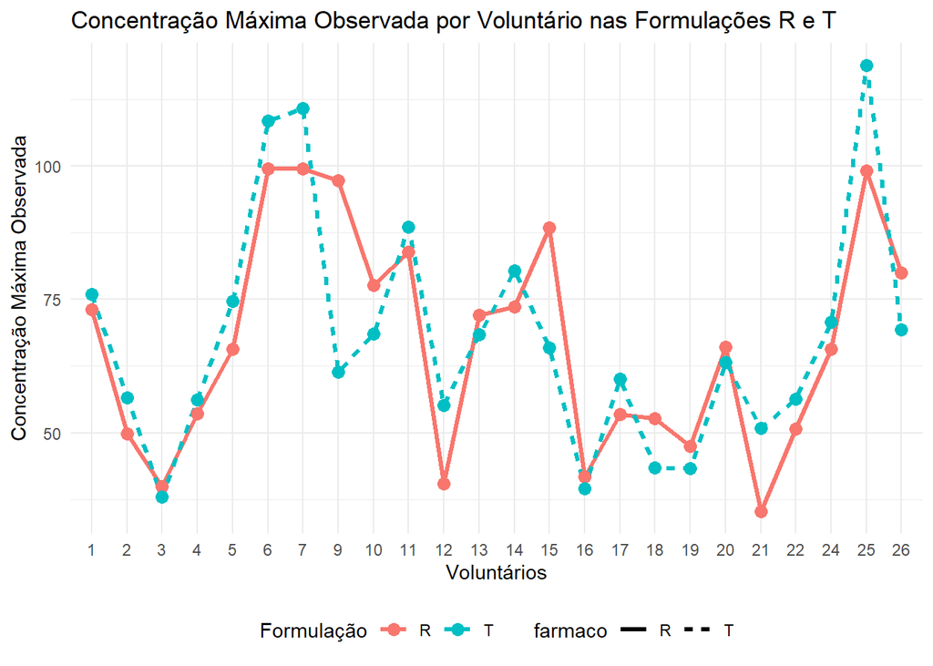

```r
# ------------------------------------------
# 6. Gráficos Comparativos e Distribuição
# ------------------------------------------

# Linha Cmax por voluntário
ggplot(final_df2, aes(x = voluntario, y = Cmax, group = farmaco, color = farmaco)) +
  geom_line(aes(linetype = farmaco), size = 1.2) +
  geom_point(size = 3) +
  labs(title = "Concentração Máxima Observada por Voluntário nas Formulações R e T",
       x = "Voluntários", y = "Concentração Máxima Observada", color = "Formulação") +
  theme_minimal() +
  theme(legend.position = "bottom")
```

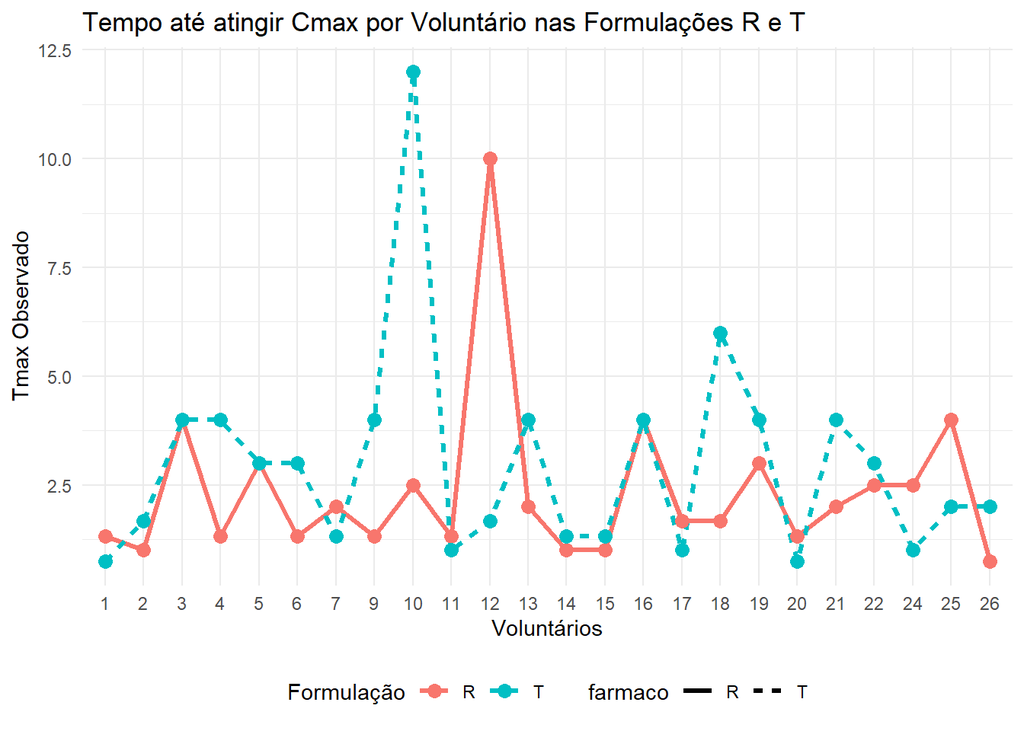

```r
# Linha Tmax por voluntário
ggplot(final_df2, aes(x = voluntario, y = Tmax, group = farmaco, color = farmaco)) +
  geom_line(aes(linetype = farmaco), size = 1.2) +
  geom_point(size = 3) +
  labs(title = "Tempo até atingir Cmax por Voluntário nas Formulações R e T",
       x = "Voluntários", y = "Tmax Observado", color = "Formulação") +
  theme_minimal() +
  theme(legend.position = "bottom")
```

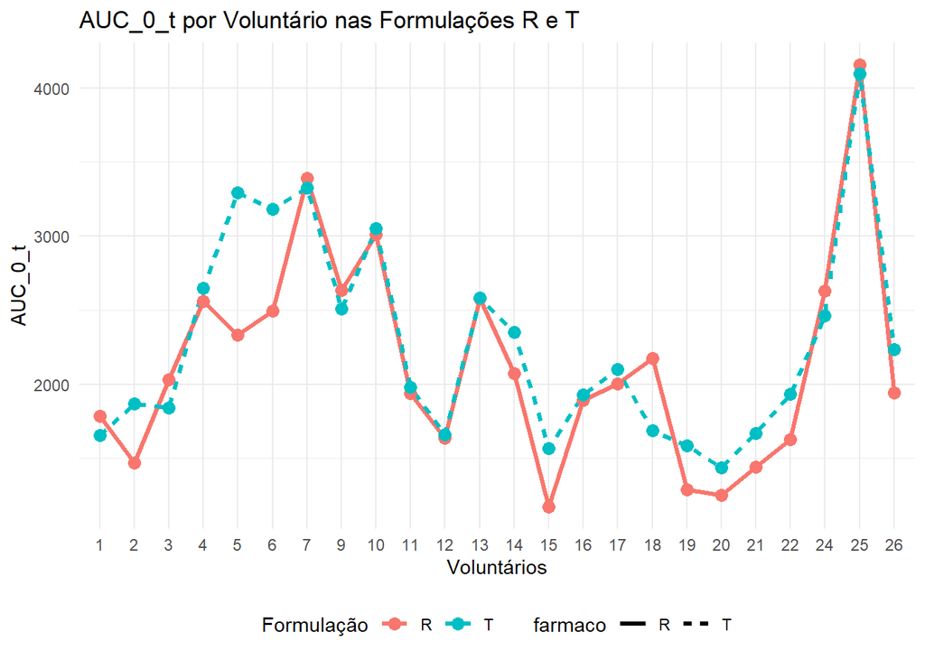

```r
# Linha ASC_k por voluntário
ggplot(final_df2, aes(x = voluntario, y = AUC_0_t, group = farmaco, color = farmaco)) +
  geom_line(aes(linetype = farmaco), size = 1.2) +
  geom_point(size = 3) +
  labs(title = "AUC_0_t por Voluntário nas Formulações R e T",
       x = "Voluntários", y = "AUC_0_t", color = "Formulação") +
  theme_minimal() +
  theme(legend.position = "bottom")
```

As formulações **R** e **T** apresentaram perfis semelhantes nos voluntários, mas com diferenças sutis: a formulação T mostrou, em média, **C_max** um pouco mais alta e **AUC0**−**t** maior, sugerindo maior extensão da absorção; o **Tmax** também foi levemente superior em **T**, indicando absorção mais lenta. Apesar dessas diferenças, a alta variabilidade entre os indivíduos exige análise estatística formal para confirmar bioequivalência.

### Pressuposto de Normalidade

Para a verificação do pressuposto de normalidade de **C_max**, necessário para os testes estatísticos do crossover (modelo misto, **ANOVA**), podemos analisar graficamente e pelo teste de **Shapiro**-**wilks**, assim escrito no manual da ANVISA.

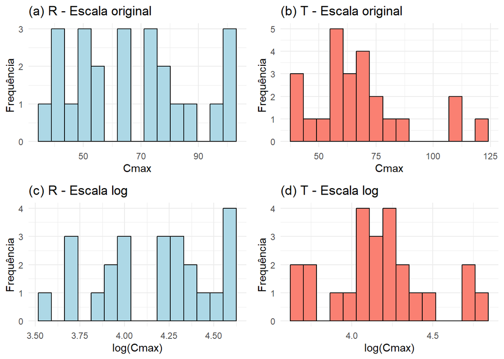

```r
# ------------------------------------------
# 7. Teste de Normalidade (Shapiro-Wilk)
# ------------------------------------------
# Histogramas de Cmax e log(Cmax)
p1 <- ggplot(final_df2 %>% filter(farmaco == "R"), aes(x = Cmax)) +
  geom_histogram(color = "black", fill = "lightblue", bins = 15) +
  labs(title = "(a) R - Escala original", x = "Cmax", y = "Frequência") +
  theme_minimal()
p2 <- ggplot(final_df2 %>% filter(farmaco == "T"), aes(x = Cmax)) +
  geom_histogram(color = "black", fill = "salmon", bins = 15) +
  labs(title = "(b) T - Escala original", x = "Cmax", y = "Frequência") +
  theme_minimal()
p3 <- ggplot(final_df2 %>% filter(farmaco == "R"), aes(x = log(Cmax))) +
  geom_histogram(color = "black", fill = "lightblue", bins = 15) +
  labs(title = "(c) R - Escala log", x = "log(Cmax)", y = "Frequência") +
  theme_minimal()
p4 <- ggplot(final_df2 %>% filter(farmaco == "T"), aes(x = log(Cmax))) +
  geom_histogram(color = "black", fill = "salmon", bins = 15) +
  labs(title = "(d) T - Escala log", x = "log(Cmax)", y = "Frequência") +
  theme_minimal()
grid.arrange(p1, p2, p3, p4, ncol = 2)
```

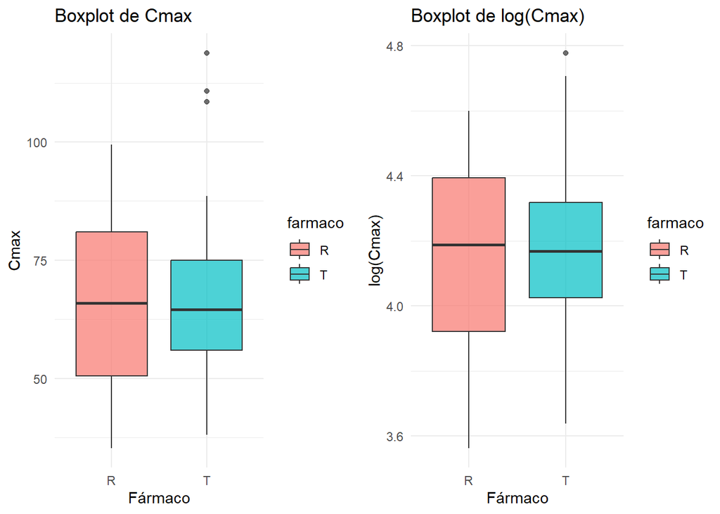

```r
# Boxplots
box1 <- ggplot(final_df2, aes(x = farmaco, y = Cmax, fill = farmaco)) +
  geom_boxplot(alpha = 0.7) +
  labs(title = "Boxplot de Cmax", x = "Fármaco", y = "Cmax") +
  theme_minimal()
box2 <- ggplot(final_df2, aes(x = farmaco, y = log(Cmax), fill = farmaco)) +
  geom_boxplot(alpha = 0.7) +
  labs(title = "Boxplot de log(Cmax)", x = "Fármaco", y = "log(Cmax)") +
  theme_minimal()
grid.arrange(box1, box2, ncol = 2)
```

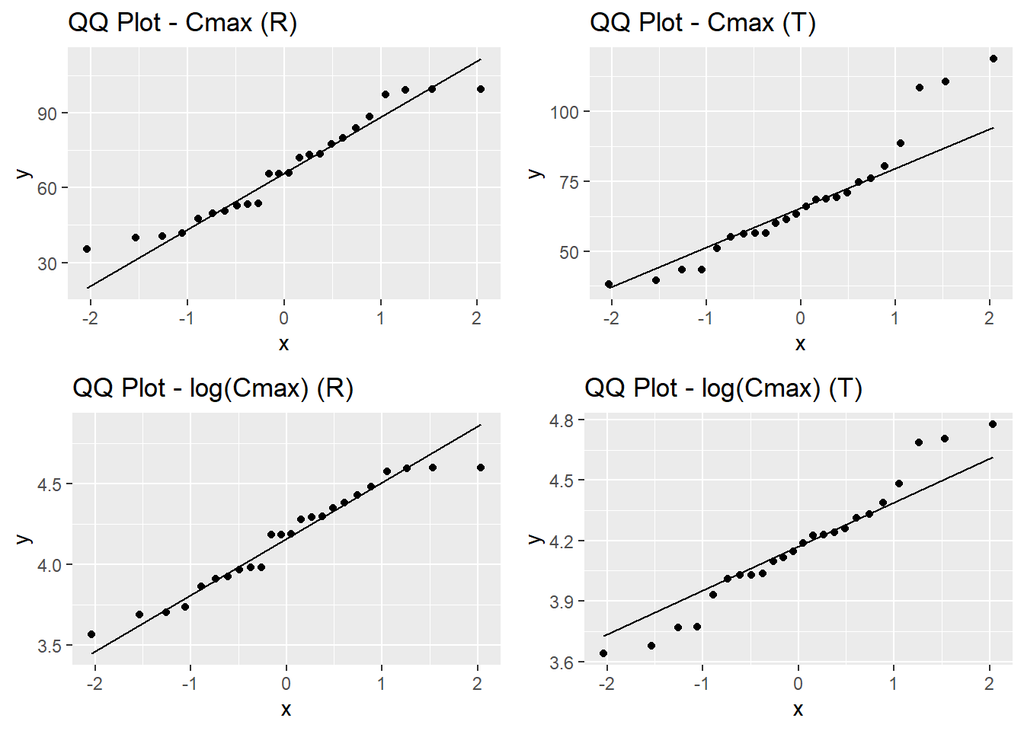

```r
# QQ plots
qq1 <- ggplot(subset(final_df2, farmaco == "R"), aes(sample = Cmax)) +
  stat_qq() + stat_qq_line() +
  labs(title = "QQ Plot - Cmax (R)")
qq2 <- ggplot(subset(final_df2, farmaco == "T"), aes(sample = Cmax)) +
  stat_qq() + stat_qq_line() +
  labs(title = "QQ Plot - Cmax (T)")
qq3 <- ggplot(subset(final_df2, farmaco == "R"), aes(sample = log(Cmax))) +
  stat_qq() + stat_qq_line() +
  labs(title = "QQ Plot - log(Cmax) (R)")
qq4 <- ggplot(subset(final_df2, farmaco == "T"), aes(sample = log(Cmax))) +
  stat_qq() + stat_qq_line() +
  labs(title = "QQ Plot - log(Cmax) (T)")
grid.arrange(qq1, qq2, qq3, qq4, ncol = 2)
```

```r
# ------------------------------------------
# 7. Teste de Normalidade (Shapiro-Wilk)
# ------------------------------------------
shapiro_tbl <- tibble::tibble(
  Farmaco     = rep(c("R", "T"), each = 2),
  Variável    = rep(c("Cmax", "log(Cmax)"), times = 2),
  W           = c(
    shapiro.test(subset(final_df2, farmaco == "R")$Cmax)$statistic,
    shapiro.test(log(subset(final_df2, farmaco == "R")$Cmax))$statistic,
    shapiro.test(subset(final_df2, farmaco == "T")$Cmax)$statistic,
    shapiro.test(log(subset(final_df2, farmaco == "T")$Cmax))$statistic
  ),
  `p-valor`   = c(
    shapiro.test(subset(final_df2, farmaco == "R")$Cmax)$p.value,
    shapiro.test(log(subset(final_df2, farmaco == "R")$Cmax))$p.value,
    shapiro.test(subset(final_df2, farmaco == "T")$Cmax)$p.value,
    shapiro.test(log(subset(final_df2, farmaco == "T")$Cmax))$p.value
  )
) %>%
  mutate(Normalidade = ifelse(`p-valor` > 0.05, "Não Rejeita", "Rejeita"))

kable(shapiro_tbl, digits = 3, align = "c", format = "markdown")
```

| Farmaco | Variável | W | p-valor | Normalidade |
| --- | --- | --- | --- | --- |
| R | Cmax | 0.936 | 0.132 | Não Rejeita |
| R | log(Cmax) | 0.944 | 0.201 | Não Rejeita |
| T | Cmax | 0.913 | 0.040 | Rejeita |
| T | log(Cmax) | 0.966 | 0.569 | Não Rejeita |

Os testes de normalidade indicaram que a variável **C_max** apresenta comportamento aproximadamente normal para o fármaco **R** (p = **0.132**), e que a transformação logarítmica melhora ainda mais esse ajuste (**p** = **0.201**). Para o fármaco **T**, a variável **C_max** não segue uma distribuição normal (p = **0.0403**), mas após a transformação logarítmica, a normalidade é atendida (**p** = **0.569)**. Assim, os resultados sugerem que a aplicação de log (**C_max**) é apropriada para análises que assumem normalidade, especialmente no caso do fármaco **T**.

### Análise Descritiva por Voluntário:

### Descritiva por Voluntário: Voluntário 1

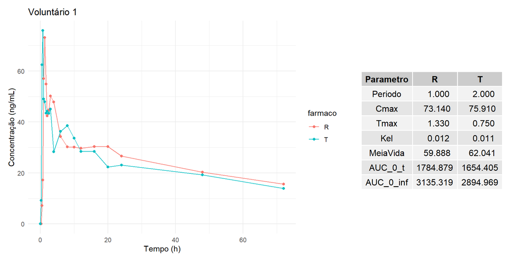

### Descritiva por Voluntário: Voluntário 2

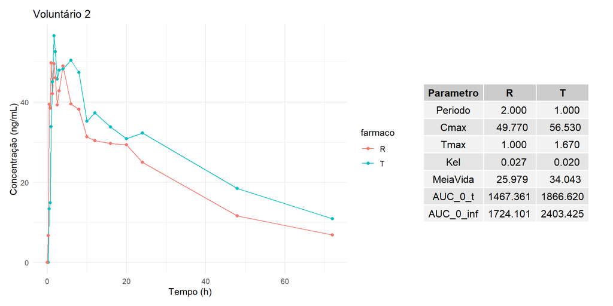

### Descritiva por Voluntário: Voluntário 3

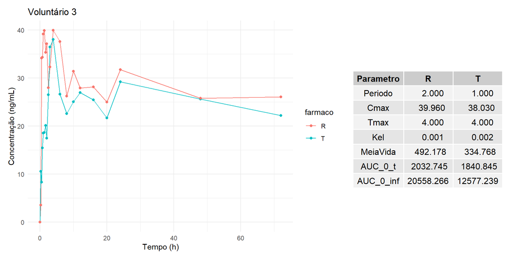

### Descritiva por Voluntário: Voluntário 4

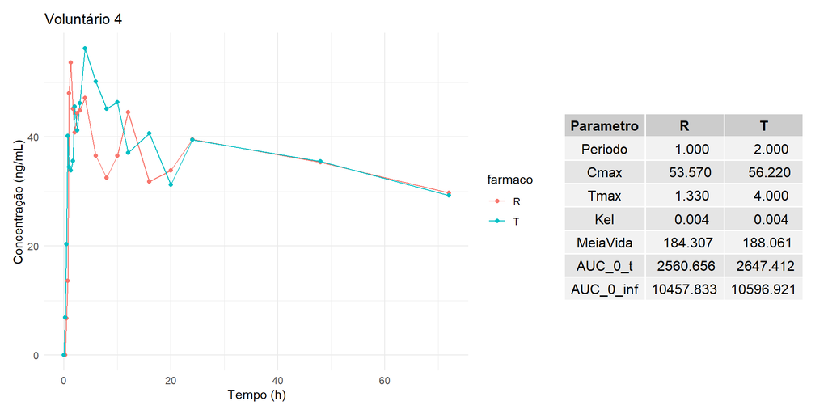

### Descritiva por Voluntário: Voluntário 5

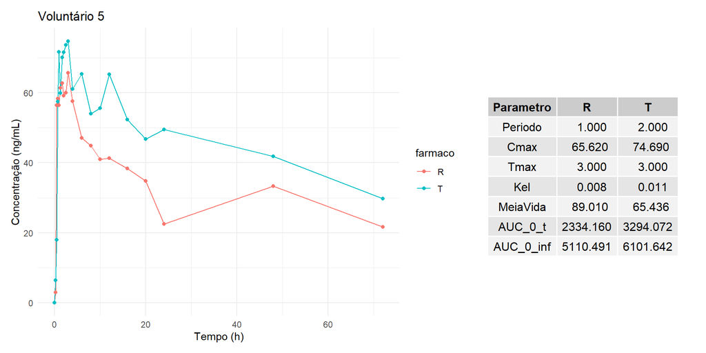

### Descritiva por Voluntário: Voluntário 6

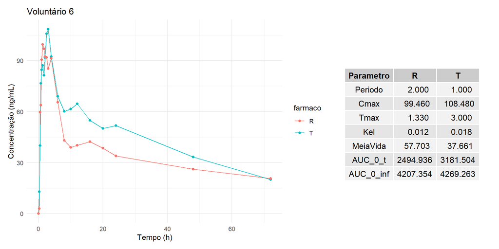

### Descritiva por Voluntário: Voluntário 7

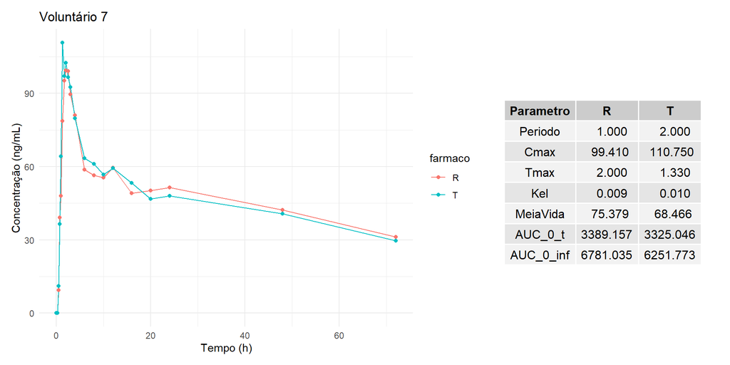

### Descritiva por Voluntário: Voluntário 9

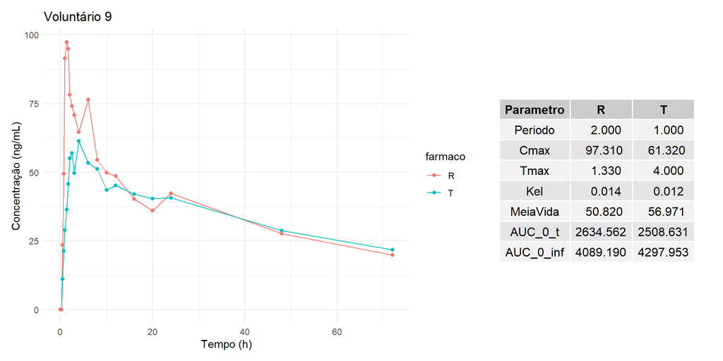

### Descritiva por Voluntário: Voluntário 10

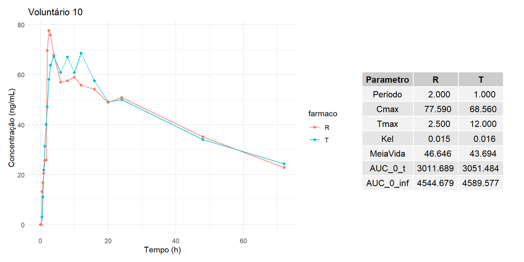

### Descritiva por Voluntário: Voluntário 11

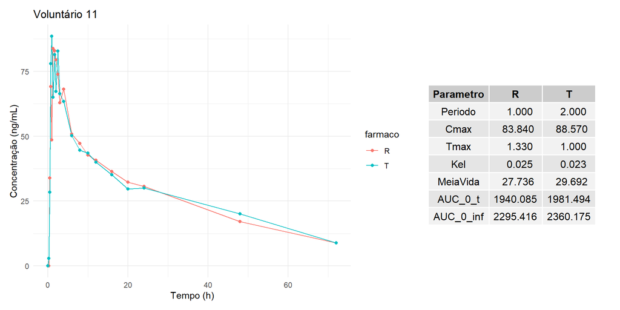

### Descritiva por Voluntário: Voluntário 12

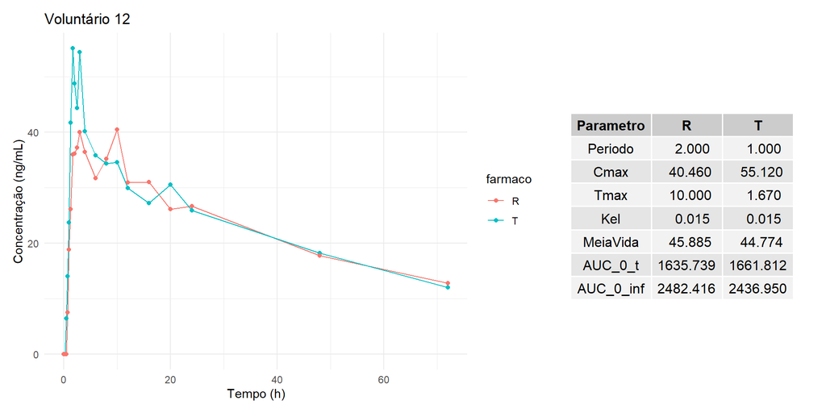

### Descritiva por Voluntário: Voluntário 13

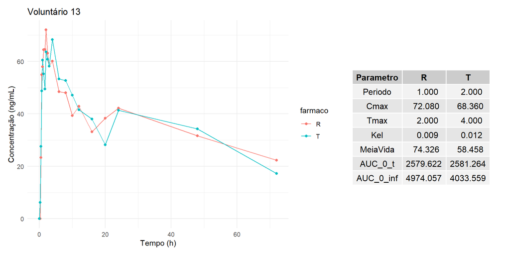

### Descritiva por Voluntário: Voluntário 14

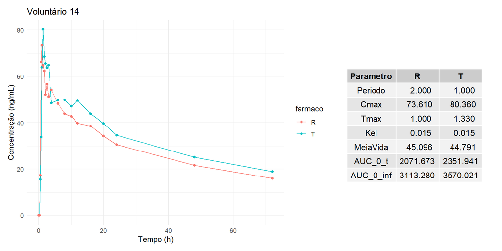

### Descritiva por Voluntário: Voluntário 15

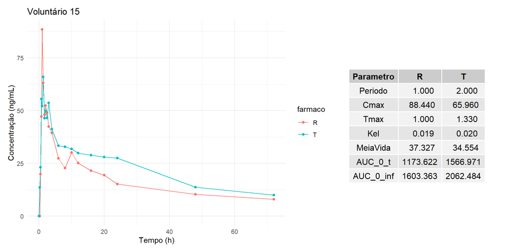

### Descritiva por Voluntário: Voluntário 16

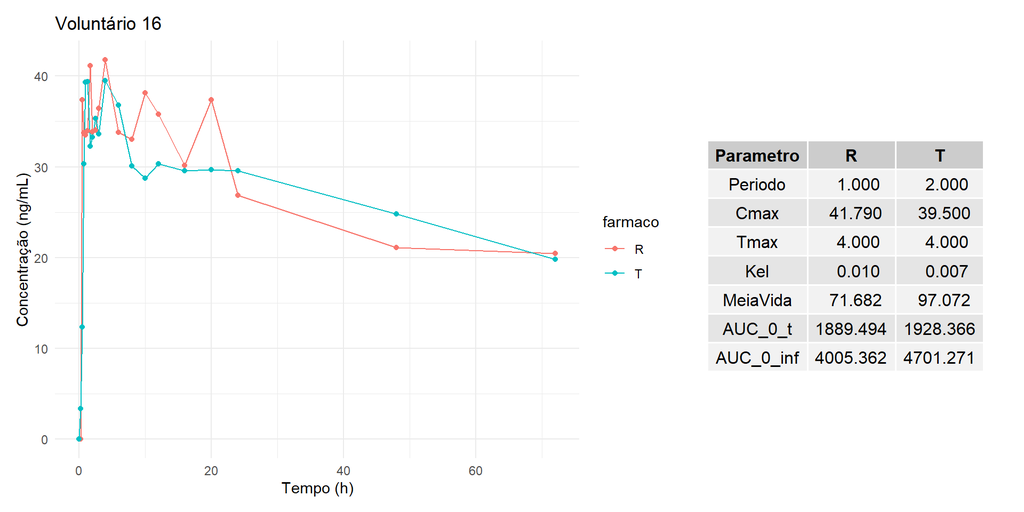

### Descritiva por Voluntário: Voluntário 17

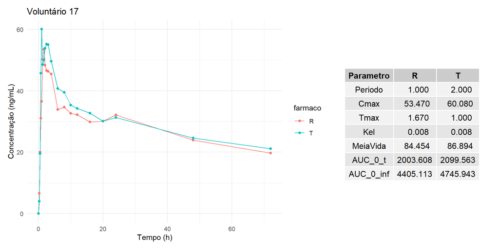

### Descritiva por Voluntário: Voluntário 18

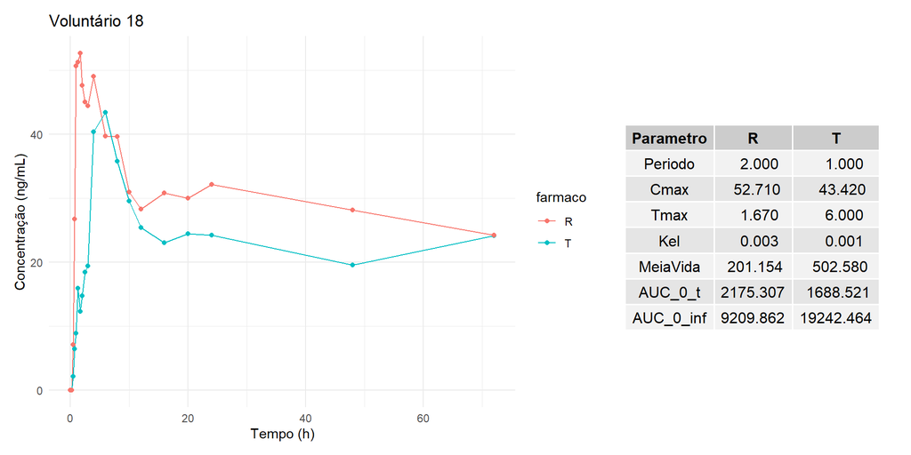

### Descritiva por Voluntário: Voluntário 19

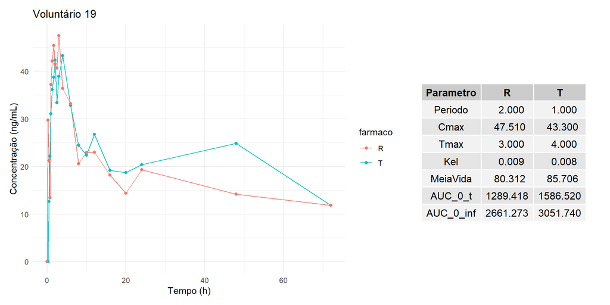

### Descritiva por Voluntário: Voluntário 20

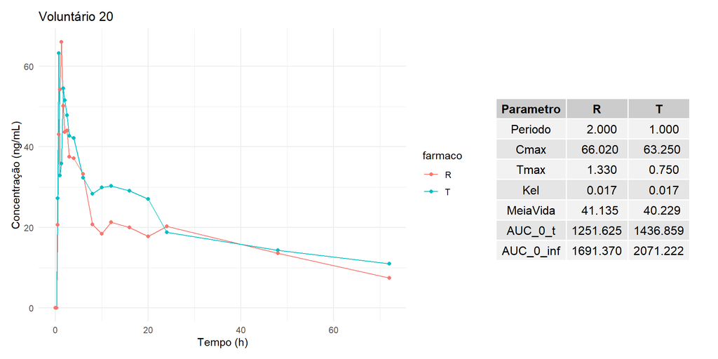

### Descritiva por Voluntário: Voluntário 21

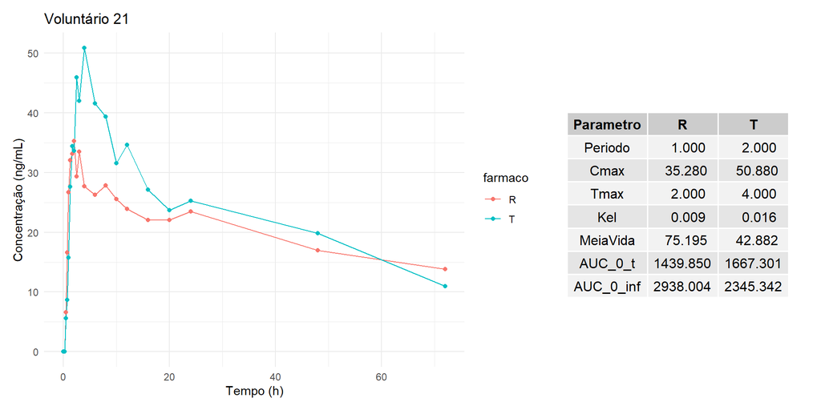

### Descritiva por Voluntário: Voluntário 22

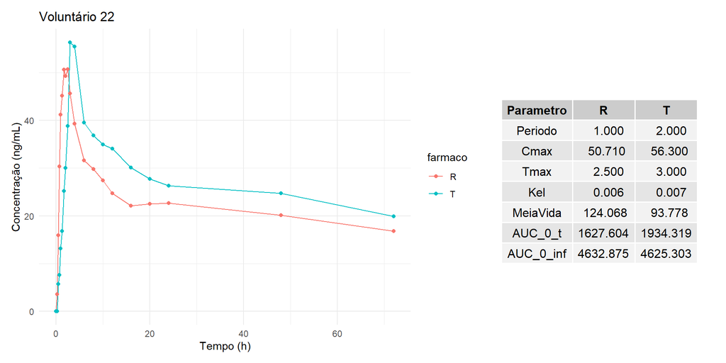

### Descritiva por Voluntário: Voluntário 24

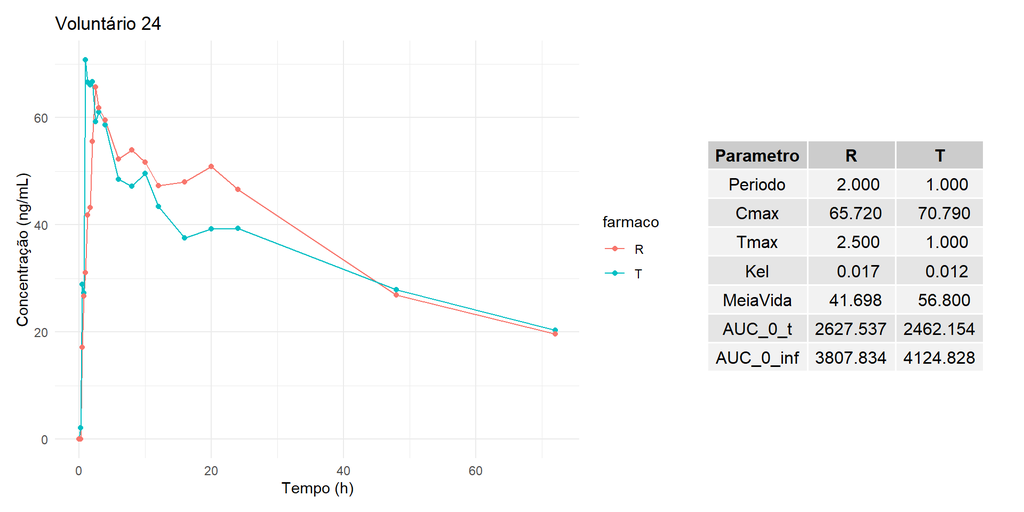

### Descritiva por Voluntário: Voluntário 25

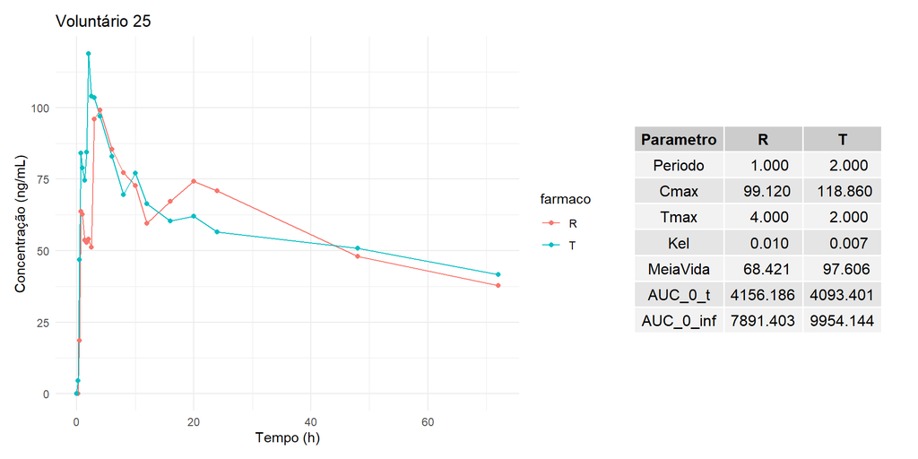

### Descritiva por Voluntário: Voluntário 26

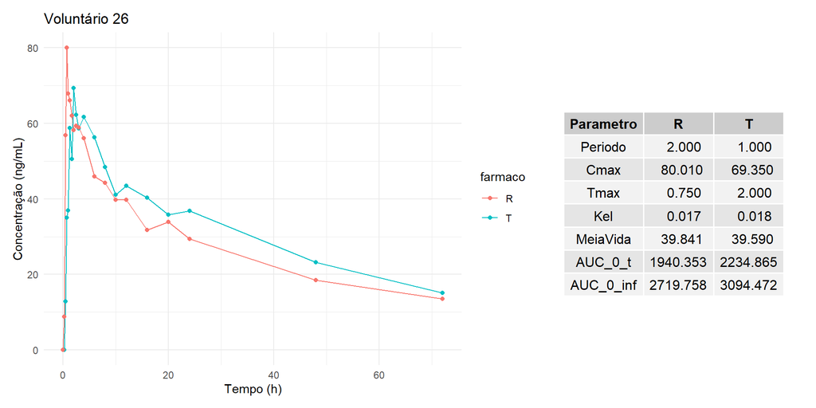

## Considerações Finais

A comparação entre os fármacos **R** e **T** mostrou parâmetros farmacocinéticos médios semelhantes, com destaque para valores próximos de **C_max**, **AUC** e **Meia**-**vida**. Os gráficos de concentração sugerem perfis compatíveis, com o **T** apresentando leve atraso no **Tmax**.

Os testes de Shapiro-Wilk indicaram que os dados de **C_max** para o fármaco **T** não seguem distribuição normal, sendo necessário o uso de log(**C_max**) para atender esse pressuposto. A transformação logarítmica também foi confirmada visualmente pelos histogramas e gráficos de probabilidade normal, tornando-a recomendada para análises estatísticas comparativas.

O próximo passo da análise seria aplicação da ANOVA para verificar possíveis diferenças estatísticas entre os fármacos, considerando os parâmetros farmacocinéticos transformados quando necessário. Em paralelo, a comparação dos intervalos de confiança para as médias permitirá avaliar a equivalência entre os tratamentos, especialmente para **C_max** e **AUC**, critérios essenciais em estudos de bioequivalência.